# Inference IV: Mixed Effects Models

Steven Luke

2026-01-02

Go To Home Page

In this unit we’ll be learning about my *favorite* type of model: mixed-effects models.

Mixed-effects models are also sometimes called:

- mixed models
- hierarchical models
- random effects models
- multilevel models

I want you to be excited about mixed-effects models, too. So let’s talk about the limitations of other tests:

|  | ANOVA | Regression |
| --- | --- | --- |
| Categorical Predictors (Groups) | **YES** | **YES** |
| Continouous Predictors (Numbers) | *no* | **YES** |
| Directly tests hypotheses (i.e. isn’t an omnibus test that requires follow-up tests) | *no* | **YES** |
| Can handle non-independent (within-subjects) data | **YES** | *no* |
| Can handle more than one source of non-independence | not well | *no* |
| Can handle missing data | not well | not well |

As a spoiler, let’s now add mixed-effects models to the list.

|  | ANOVA | Regression | Mixed-effects Models |
| --- | --- | --- | --- |
| Categorical Predictors (Groups) | **YES** | **YES** | **YES** |
| Continouous Predictors (Numbers) | *no* | **YES** | **YES** |
| Directly tests hypotheses (i.e. isn’t an omnibus test that requires follow-up tests) | *no* | **YES** | **YES** |
| Can handle non-independent data | **YES** | *no* | **YES** |
| Can handle more than one source of non-independence | not well | *no* | **YES** |
| Can handle missing data | not well | not well | **YES** |
| Will impress Taylor Swift | *no* | *no* | I hope so! |

Mixed-effects models can have a lot of pro’s and few con’s, is what I’m telling you.

# Video Tutorial

https://byu.box.com/s/0xlyghcfkgz4kunnffnnaxot5vhnbtjg

# What is a Mixed-Effects Model?

A mixed-effects model is ‘mixed’ because it contains two kinds of ‘effects’:

- **Fixed Effects:** These are the *predictors* in a regression; the variables we want to test.
- **Random Effects:** These are grouping factors, variables that represent groups or categories that exist in the data (specifically the dependent variable). Random effects help us to account for non-independence in our data.

## Nested data

We’ve talked about within-subjects data already: data where multiple data points come from the same source (e.g. the same ‘subject’). Within-subjects data is ‘nested data’, as if the data points are fragile little eggs gently nested within the person who provided those data points.

If data is ‘nested’, then it is not independent. What makes data non-independent? Well, let’s start by considering some examples of data that *is* independent:

- A large-scale survey randomly samples from the entire US population. Each person is asked which of two candidates they plan to vote for. ([“It’s a two party system. You have to vote for one of us!”](https://www.youtube.com/watch?v=w7NeRiNefO0))
- A doctor randomly measures the blood pressure of 100 people to see whether males or females are at greater risk of hypertension.

In independent data, each observation is separate from each other observation - there is no reason to think that one data point could be logically grouped with another. This means that each participant gives only one data point.

**Most data is not independent**. Instead, the data can be grouped in some way.

- A longitudinal study of child nutrition collects data on the diets of 100 children once a year for 10 years. So, each child gives 10 data points to the study. These data points are not independent, because they come from the same child.
- A farmer is taking a sample of his potato crop to see how well it is doing. He takes 10 potatoes from each of his 5 fields. Because each group of 10 potatoes comes from the same field, these potatoes are not independent observations.
- A state official is analyzing the results of a state-wide high school science test. Although each student only provides one data point, the students can be logically grouped depending on which high school they attend. Since different high schools differ in the quality of their science instruction (as well as in many other ways), the scores of the students who attend a given high school are not truly independent of each other.
- A group of 20 language-impaired children take a picture naming test, and the therapist examines their accuracy at naming each of the 100 pictures. Because the same pictures were used for each participant, there are 20 observations for each picture. These data points are not independent, because they are all in reponse to the same picture.

Data like this that contains groups of inter-related data points is known as *nested data*. Mixed-effects models are tailor-made to handle nested data.

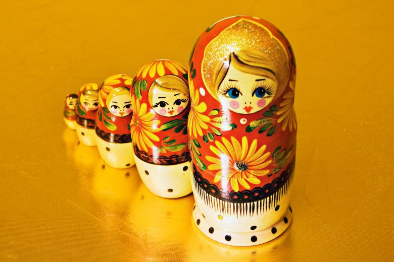

Sometimes data can be nested within nests:

- An educational psychologist is comparing two instructional techniques. Students in 6 different classrooms are taught a history lesson using method A for one unit and method B for the other unit. After each unit, the students take a test. So, each student provides two data points, one after each unit. These two data points are nested within student. But the students themselves are nested within classrooms - students in the same classroom have the same teacher, so their scores are not independent of each other. That’s two ‘nests’: student and classroom.

Other times a given data point can fit into several different nests.

- A cognitive psychologist has 50 participants read 20 different passages and assesses their comprehension; Each participant answers 5 comprehension questions about each passage. So, the answers to the questions are nested within participant. But they are also nested (separately) within text passage, because responses to the same texts are not independent of each other.

Nested data is actually quite common. In fact, while many textbook examples are independent data, I would argue that most real-world data sets are nested data.

## What does nested data look like?

### Example 1: Sleep Study

In this hypothetical example, we have our Subjects come into the lab twice on two separate nights. On one night, we give the subject a dose of caffeine before bed. On the other night, we don’t. Then we measure their sleep quality.

- *Dependent Variable*: Sleep Quality, a number
- *Independent Variable*: Treatment (Levels: Caffeine, No Caffeine)

Take a look at the data below, and answer the following questions for yourself:

- Is the data nested within **Subject**?
- Is the data nested within **Night**?

```
## # A tibble: 6 × 4
##   Subject Night Treatment   Sleep_Quality
##   <chr>   <dbl> <chr>               <int>
## 1 Abel        1 Caffeine               92
## 2 Abel        2 No Caffeine            25
## 3 Caleb       2 Caffeine               72
## 4 Caleb       1 No Caffeine            83
## 5 Calvin      1 Caffeine               32
## 6 Calvin      2 No Caffeine            75
```

The data **is** nested within Subject. You can see that each Subject provided 2 data points.

The data **is** nested within Night. There are 3 data points for Night = 1 and 3 for Night = 2.

### Example 2: Empathy

Let’s imagine a study where we had participants read different books and then measured their empathy. Some of the books belong to the ‘Literary Fiction’ genre (e.g. The Great Gatsby, A Tale of Two Cities), while others are Non-fiction.

- *Dependent Variable*: Empathy, a number
- *Independent Variable*: Genre (Levels: Literary Fiction, Non-Fiction)

Take a look at the data below, and answer the following questions for yourself:

- Is the data nested within **Subject**?
- Is the data nested within **Book**?

```
## # A tibble: 8 × 4
##   Subject  Genre            Book                                    Empathy
##   <chr>    <chr>            <chr>                                     <dbl>
## 1 Tim      Literary Fiction Pride & Prejudice                             5
## 2 Jane     Literary Fiction Pride & Prejudice                             6
## 3 Margot   Literary Fiction To Kill a Mockingbird                         4
## 4 Joseph   Literary Fiction To Kill a Mockingbird                         9
## 5 William  Non-Fiction      Where do Potatoes Come From?                  2
## 6 Crandall Non-Fiction      Where do Potatoes Come From?                  4
## 7 Giacomo  Non-Fiction      Taylor Swift: An Unauthorized Biography       9
## 8 Aaron    Non-Fiction      Taylor Swift: An Unauthorized Biography    1989
```

Each participant reads only one book and gives only one data point, so our data is **not** nested within Subjects. You can see this clearly in the data - each Subject’s name is repeated only once.

However, we use the same book for multiple subjects, so our data **is** nested within Book. Again, you can see this clearly in the data; the book title is repeated.

### Example 3: Vocabulary Learning

Here’s a real example from the *heplots* package: a dataset called VocabGrowth. In this longitudinal dataset, a group of children were followed from grades 8-11, and their vocabulary was measured each year. It is clear that the data is nested, because the Student number is repeated.

I cleaned up this data for you; it was originally wide data. That’s a clue - *wide data is pretty much always nested data.*

```
## # A tibble: 256 × 3
##    Student Grade Vocab_Score
##    <chr>   <dbl>       <dbl>
##  1 1           8        1.75
##  2 1           9        2.6
##  3 1          10        3.76
##  4 1          11        3.68
##  5 2           8        0.9
##  6 2           9        2.47
##  7 2          10        2.44
##  8 2          11        3.43
##  9 3           8        0.8
## 10 3           9        0.93
## # ℹ 246 more rows
```

## Random Effects vs. Fixed Effects

Now that we know what nested data *is*, we are ready to discuss random effects. A random effect is a parameter in our model that accounts for the nested character of our data. In other words, a random effect tells the model which data points are nested and not independent.

### How are fixed effects and random effects different?

In short, fixed effects represent the variables we are interested in, while random effects represent the variables we think might affect the outcome of our study but that we don’t care about directly.

| Fixed Effects | Random Effects |
| --- | --- |
| Is related to our hypothesis | Is NOT related to our hypothesis |
| Represents a variable we want to test | Is a nuisance variable that we want to control for |
| Values were specifically chosen | Values were selected at random from a larger group |
| Can be either categorical or continuous | MUST be categorical |

Imagine a simple study where we measure how many hours each student studies for each of the 10 quizzes they take in our class, and we want to see if this predicts quiz scores. Study Time is obviously a fixed effect; we care about it, and we want to test it.

But do we care about Student? Obviously we care about students as human beings, at least to the extent necessary to avoid being called a ‘sociopath’. But we are not interested in the students as a fixed effect; we didn’t mention the students in our hypothesis, and we won’t write a paper entitled “How Tim Did on His Quizzes”. The students represent the sample, and we want to generalize beyond these individual students to the population as a whole. That’s why student is a good random effect in this study.

We do know that the students differ from each other in many ways: age, IQ, sleep habits, educational background, stress, mental health, number of parasocial relationships with musician-celebrities, and more. Our study isn’t about these things, but we know they can affect quiz scores. We could try to measure them all and put them into a regression as co-variates, but we don’t have to! Instead, we can just make student a random effect. As you’ll see, adding random effects makes adjustments to our model based on who is taking the quizzes. This effectively ‘controls for’ all the ways that each student differs from each other student, and allows us to focus on what’s important: the fixed effects.

Let’s practice figuring out whether some variable is a fixed or random effect.

#### Example 1: Reaction Time Data

Here’s another example from the *heplots* package: a dataset called ReactTime. In this dataset, participants responded to stimuli presented at different angles. Sometimes noise was present, sometimes not.

We have 4 columns in this dataset: Subject, Angle, Noise, and Reaction_Time. Reaction_Time is the dependent variable.

Subject is our random effect - since each subject provided multiple data points, we want to group the data by Subject. Subject is NOT a fixed effect because it’s not the thing we’re studying; we’re not trying to learn something about how Subject influences Reaction_Time.

Like Subject, Angle and Noise are repeated in the data, but they are not random effects - Angle and Noise are fixed effects. Why? Because we chose these values specifically - we want to learn how Angle and Noise influence Reaction_Time.

Also, the Subjects is this study were **randomly** chosen from a larger population of people, so they should be a random effect. The values of Angle and Noise were *specifically* chosen by the person who set up the study - they were **fixed** by the experimenter. If you were to redo this study, you would have different subjects, but the same values for Angle and Noise.

```
## # A tibble: 60 × 4
##    Subject Angle Noise   Reaction_Time
##    <chr>   <dbl> <chr>           <dbl>
##  1 1           0 Absent            420
##  2 1           4 Absent            420
##  3 1           8 Absent            480
##  4 1           0 Present           480
##  5 1           4 Present           600
##  6 1           8 Present           780
##  7 2           0 Absent            420
##  8 2           4 Absent            480
##  9 2           8 Absent            480
## 10 2           0 Present           360
## # ℹ 50 more rows
```

#### Example 2: Sleep Study

Consider our hypothetical sleep study, above. In this example, we decided that Subject and Night were random effects. Subject is a random effect in this study for the same reason it was a random effect in the Reaction Time study. Night is a random effect because 1) it is a grouping factor - it is repeated multiple times in the data and 2) we don’t want to test it directly. The study is not *about* whether people had caffeine on night 1 or night 2. In fact, Night was randomized because we don’t want it to have an effect on our results. Since it was randomized, it should be a random effect.

But Caffeine is a fixed effect because 1) it’s the variable we care about and want to test and 2) we, as the experimenters, *fixed* (decided on) the different values for Caffeine.

#### Example 3: Empathy

In our hypothetical empathy study above, participants read one of 4 different Books from 2 different Genres: Literary Fiction and Non-Fiction. Book is a random effect because 1) we don’t care about those books specifically and 2) we could have chosen different books - these books were selected at random from the broader Genre. Genre is a fixed effect because 1) this is the variable we care about and want to test and 2) we specifically chose these two Genres to include in our study.

## Other (inferior) ways to handle nested data

So mixed-effects models are the best way to handle nested data. But there are others. We’ve already seen a couple of other ways to handle nested data:

- Paired-sample *t*-tests are used when both observations come from the same subject (i.e. the observations are *nested* within subject).
- Repeated-measures ANOVAs include an additional error term that acknowledges the nested nature of the data set.

However, these methods are highly restricted in the kinds of nested data they can handle. Paired-sample *t*-tests can only handle a single nesting factor, and only two observations per ‘nest’. Repeated-measures ANOVAs can accept more observations per nest, but again can only handle a single nest at a time. Mixed-effects models do not suffer from these limitations.

1. Look at this data. Is it nested data? How do you know?
2. What is/are the fixed effect variable(s)? If the data is nested, what variable(s) would make a good random effect?

```
##    Quiz Johnny_Appleseed Paul_Bunyan John_Henry
## 1     1               52          62         55
## 2     2               51          62         50
## 3     3               52          59         50
## 4     4               54          55         44
## 5     5               51          56         48
## 6     6               52          63         51
## 7     7               49          60         54
## 8     8               47          60         52
## 9     9               52          62         49
## 10   10               51          58         49
```

3. Look at this data about cars. Is it nested data? How do you know?
4. What is/are some possible fixed effect variable(s)? If the data is nested, what variable(s) would make a good random effect?

```
##                    mpg cyl disp  hp drat    wt  qsec vs am gear carb  hp_cat
## Mazda RX4         21.0   6  160 110 3.90 2.620 16.46  0  1    4    4     Low
## Mazda RX4 Wag     21.0   6  160 110 3.90 2.875 17.02  0  1    4    4     Low
## Datsun 710        22.8   4  108  93 3.85 2.320 18.61  1  1    4    1  Lowest
## Hornet 4 Drive    21.4   6  258 110 3.08 3.215 19.44  1  0    3    1     Low
## Hornet Sportabout 18.7   8  360 175 3.15 3.440 17.02  0  0    3    2 Average
## Valiant           18.1   6  225 105 2.76 3.460 20.22  1  0    3    1     Low
```

5. Now look at this data about dogsledding. Is it nested data? How do you know?
6. What is/are some possible fixed effect variable(s)? If the data is nested, what variable(s) would make a good random effect?

| Musher | Checkpoint | Time |
| --- | --- | --- |
| Jerry Sousa | 1 | 243 |
| Jerry Sousa | 2 | 176 |
| Jerry Sousa | 3 | 304 |
| Jerry Sousa | 4 | 201 |
| Melissa Owens | 1 | 215 |
| Melissa Owens | 2 | 421 |
| Melissa Owens | 3 | 334 |
| Melissa Owens | 4 | 220 |

7. Now look at this data about diamonds. Is it nested data? How do you know?
8. What is/are some possible fixed effect variable(s)? If the data is nested, what variable(s) would make a good random effect?

```
## # A tibble: 6 × 10
##   carat cut       color clarity depth table price     x     y     z
##   <dbl> <ord>     <ord> <ord>   <dbl> <dbl> <int> <dbl> <dbl> <dbl>
## 1  0.23 Ideal     E     SI2      61.5    55   326  3.95  3.98  2.43
## 2  0.21 Premium   E     SI1      59.8    61   326  3.89  3.84  2.31
## 3  0.23 Good      E     VS1      56.9    65   327  4.05  4.07  2.31
## 4  0.29 Premium   I     VS2      62.4    58   334  4.2   4.23  2.63
## 5  0.31 Good      J     SI2      63.3    58   335  4.34  4.35  2.75
## 6  0.24 Very Good J     VVS2     62.8    57   336  3.94  3.96  2.48
```

9. Now look at this data about response times to different stimuli and tasks, below, and read this description of the data: https://search.r-project.org/CRAN/refmans/Stat2Data/html/VisualVerbal.html. Is it nested data? How do you know?
10. What is/are some possible fixed effect variable(s)? If the data is nested, what variable(s) would make a good random effect?

```
##   Subject   Task Report          Group  Time
## 1      s1 Visual Visual   Letter Point 11.60
## 2      s1 Visual Verbal     Letter Say 13.06
## 3      s1 Verbal Visual Sentence Point 16.05
## 4      s1 Verbal Verbal   Sentence Say 11.51
## 5     s10 Visual Visual   Letter Point 16.10
## 6     s10 Visual Verbal     Letter Say  5.88
```

11. Now look at this data about Adopted Children, below, and read this description of the data: https://friendly.github.io/heplots/reference/Adopted.html. Is it nested data? How do you know?
12. What is/are some possible fixed effect variable(s)? If the data is nested, what variable(s) would make a good random effect?

```
##    AMED BMIQ Age2IQ Age4IQ Age8IQ Age13IQ
## 1    10  100    120    115    109     106
## 2    10   71    131    109    113      95
## 3    14   89    126    115    113      90
## 4     7   73    120    102    111     121
## 5    14   64    126    125    114      96
## 6     8   64    125    109     96      87
## 7    13  104    105    107    106     104
## 8    16   76    130    112    124     125
## 9    10   81    107    120    109     115
## 10    8   78    104    108    125     124
```

13. Run the code below, and examine the data and the help page. Is this data nested data? How do you know?
14. What is/are some possible fixed effect variable(s)? If the data is nested, what variable(s) would make a good random effect?

```r
VerbAgg
?VerbAgg
```

15. In your own words, explain why we must treat nested data differently, statistically speaking, than non-nested data.
16. In your own words, explain the difference between a fixed effect and a random effect.

# What do we need to know about mixed-effects models?

We learned previously that there are 4 things we need to know about any statistical test:

- What variables can the test handle?
- What statistic does the test generate?
- What distribution does the test use?
- What arguments does the R function require?

Let’s talk about these 4 needs in relation to our next test: mixed effects models.

One thing you will notice quickly is that mixed-effects models are highly similar to regression. In fact, everything you just learned about regression applies directly to mixed-effects models. They’re really just a fancy regression specifically made for nested data.

# Variables

## Dependent Variables

You should know what to expect here at this point: a mixed-effects model usually takes a single numeric dependent variable.

## Independent/Predictor Variables (Fixed Effects)

Mixed-effects models are *just like regression*: they can take any number of both categorical and continuous variables as fixed effects.

17. A mixed-effects model needs a *dependent* variable. What sort of variable (number, factor, string) should this *dependent* variable be?
18. How many *dependent* variables can a mixed-effects model take (typically)?
19. A regression needs *predictor/independent variable(s)*. What sort of variable (number, factor, string) should these be?
20. How many variables can an ANOVA take as *predictor/independent variable(s)*?
21. How many levels can a given *predictor/independent variable* have in a mixed-effects model?
22. Is a mixed-effects model more like a regression or an ANOVA, in terms of the variables it can accept?
23. Describe a hypothetical study where a mixed-effects model would be the appropriate test to use and a regression would not be.
24. Describe a hypothetical study where a mixed-effects model would be the appropriate test to use and an ANOVA would not be.

# Statistic

Again, just like regression: the *t* statistic is used here.

BUT obtaining the *t* statistic for mixed-effects models is a bit more complicated.

1. Find the parameters:
   - The estimate (i.e. regression coefficient, slope of the line)
   - The standard error
2. Divide the estimate by the standard error to get the t value
3. Figure out the degrees of freedom

## 1. Find the Parameters

The regression coefficient and standard error are obtained differently in mixed-effects models than in regression. Regression uses the *ordinary least squares* (OLS) method for obtaining the regression coefficient and standard error. This method is based on minimizing the sum of squared residuals, as we saw earlier. This method uses explicit equations, and so it is possible (although not fun) to compute regression coefficients by hand.

Mixed-effects models use a different method called *restricted maximum likelihood* (REML) instead. Here are a few highlights of this method:

- I’ll use the word **parameter** a lot in this section. A model parameter is some number the model generates from the data, such as an intercept, a coefficient, or a standard error. These are numbers that can vary, and if you change them you have a different model.
- You need a computer to do REML for you - there’s no simple formula you can use.
- The computer works *iteratively*, going through repeated stages to try and fit the model.
- In the first iteration, the computer makes an educated guess on what a parameter should be, then tests that guess against the data to see if it is a good guess
- On subsequent iterations, the computer adjusts the parameter based on the results of previous iterations, moving it back and forth repeatedly until it *converges* on the number that best fits the data.

Consider the graph below, which shows how the parameter estimates changed across the iterations. Notice how the estimate of the fixed effect (top panel, red circles) starts out higher, fluctuates for a while, and then eventually settles into a pretty stable pattern. This ‘settling into a stable pattern’ is called *convergence* - the model has found the best number for this parameter.

You can see this same general trend - starting out with a guess and then adjusting it over time until the guess remains the same for several iterations - in the bottom 2 panels (standard errors).

The intercept (2nd panel, blue circles) converged immediately - the model’s guess was right the first time.

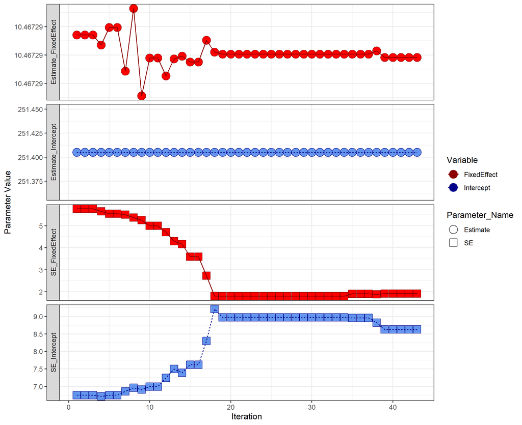

How convergence works

### Mixed Models and the Problem of Convergence

[figure not shown]

Because the parameters are ‘discovered’ via an iterative process rather than ‘computed’, it is sometimes possible that the model never ‘converges’ on a best solution. In other words, sometimes the computer can’t decide which number best fits the data. When this happens, we say that the model ‘did not converge’ or ‘failed to converge’.

Here’s what non-convergence looks like:

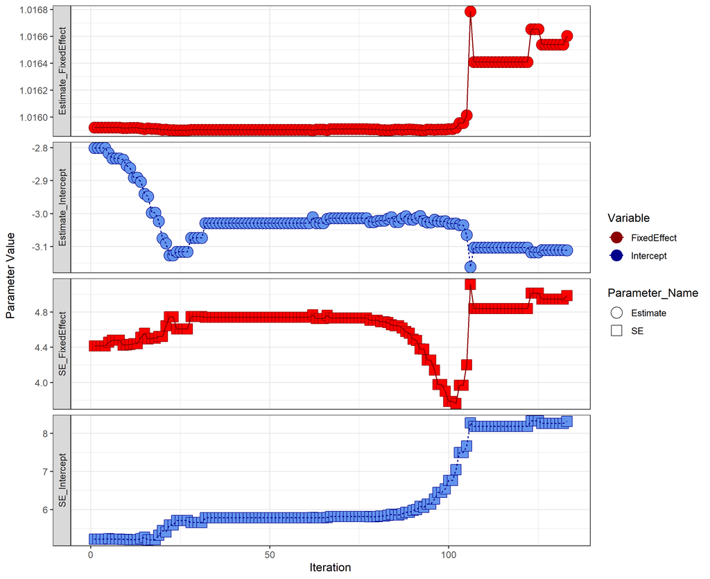

Notice how the parameters - especially the fixed effect - never really settle on a good number. When this happens, the model output will give you a warning, which will look something like this:

```
## Warning in checkConv(attr(opt, "derivs"), opt$par, ctrl = control$checkConv, : Model failed to converge with max|grad| = 0.244247 (tol = 0.002,
## component 1)
```

```
## Warning in checkConv(attr(opt, "derivs"), opt$par, ctrl = control$checkConv, : Model is nearly unidentifiable: very large eigenvalue
##  - Rescale variables?
```

This error means that the model couldn’t settle on one or more parameters.

Other times, you might experience a related error; a warning about ‘singular’ fits. This one isn’t as bad - it just means you don’t need some of your random effects parameters, because they are not doing much for the model.

```
## boundary (singular) fit: see help('isSingular')
```

#### What should you do about these errors?

In both cases, the most likely problem is that your model is **overfitted**: there are too many parameters for the data. In other words, you need to simplify the model. Usually, this means simplifying the *random effects*. Take out random slopes first, then move on to random intercepts. What are random slopes and intercepts? We’ll get to that in a moment.

**Nerdy Aside**: Some people argue that the random effects should be left in even if the model doesn’t converge, and that other changes should be made, such as using a different ‘optimizer’ to help the model converge. For now, let’s just stick with taking out random effects until the model converges - but if you find yourself regularly using mixed-effects models you’ll want to find out more about best practices here.

### The other problem: speed

Because mixed-effects models use an iterative process to converge on the model parameters, it means that these models need much more computing power than other statistical methods. In other words, be prepared to wait a while if you are running a mixed-effects model. Ideally, you want to run these on the best computer you have access to.

25. Define the following terms:
    - Parameter
    - Iterative
    - Convergence
    - Overfitted
26. In your own words, explain how the parameters of a mixed-model are obtained.
27. In your own words, explain what it means when “the Model failed to converge”. What happened?
28. If you got the “Model failed to converge” error, what should you do with your model, generally speaking?

## 2. Divide the estimate by the standard error to get the *t* value

Once your model has converged and provided you with estimates and standard errors, getting the *t*-values is easy.

This step is the same as in regression.

## 3. Figure out the degrees of freedom

This step is NOT the same as in regression. Figuring out the degrees of freedom in a mixed-effects model is not a trivial task. Is it the number of data points? No, because the data points are not independent - some ‘degrees of freedom’ have been lost. How many? Perhaps the degrees of freedom should be based on the number of groups instead, or on some combination of those two numbers. Also, many data sets are not balanced, so there are different numbers of observations in each group. This further complicates the calculation of the degrees of freedom.

So by default R just doesn’t calculate degrees of freedom. It just gives you a *t* value and leaves you to fend for yourself.

One way you can deal with that is to use an approximation method to estimate the degrees of freedom. By loading the *lmerTest* package, we can tell R to give us a good guess about what the degrees of freedom should be for each fixed effect. If you want more information, here’s a paper for you: (https://link.springer.com/article/10.3758/s13428-016-0809-y)

29. Why doesn’t R want to give us the degrees of freedom for mixed-effects models? What do we have to do to convince R to approximate the degrees of freedom?

# Distribution

Like regression, mixed models use the *t* distribution.

Once we have our *t*-statistic and degrees of freedom, we can use the *t* distribution to obtain some *p*-values.

# Arguments

To show you how to construct a mixed model, we’ll go through these steps:

1. Load packages
2. Set up a Regression
3. Add Random Intercepts
4. Add Random Slopes

## 1. Load Packages

To start, we need to load some packages. We’ll load two:

- *lme4*, the package that lets us do mixed modeling
- *lmerTest*, the package that helps us get *p* values for our models

```r
if (!require("lme4")) install.packages("lme4")
library(lme4) # This one lets you do mixed-effects models
if (!require("lmerTest")) install.packages("lmerTest")
library(lmerTest) # This one gives you p-values
```

Add the above code TO YOUR SETUP CHUNK.

## 2. Set up a regression

So how do we set up a mixed model in R? We start by setting up a regression model. First, let’s look at some data that comes with the lme4 package

```r
head(sleepstudy, n = 10)
```

```
##    Reaction Days Subject
## 1  249.5600    0     308
## 2  258.7047    1     308
## 3  250.8006    2     308
## 4  321.4398    3     308
## 5  356.8519    4     308
## 6  414.6901    5     308
## 7  382.2038    6     308
## 8  290.1486    7     308
## 9  430.5853    8     308
## 10 466.3535    9     308
```

This data comes from a study of sleep deprivation. In this study, the researchers brought in several subjects and measured their reaction time (i.e. how quickly they responded to a presented stimulus) every day for 10 days. During this time, subjects were deprived of sleep. So, the variables in the study are:

- *Dependent Variable*: Reaction, a number representing reaction time in milliseconds
- *Predictor*: Days, a number representing how many days of sleep deprivation the subject has experienced.

```r
sleep.regression <- lm(Reaction ~ Days, data = sleepstudy)
summary(sleep.regression)
```

```
##
## Call:
## lm(formula = Reaction ~ Days, data = sleepstudy)
##
## Residuals:
##      Min       1Q   Median       3Q      Max
## -110.848  -27.483    1.546   26.142  139.953
##
## Coefficients:
##             Estimate Std. Error t value             Pr(>|t|)
## (Intercept)  251.405      6.610  38.033 < 0.0000000000000002 ***
## Days          10.467      1.238   8.454  0.00000000000000989 ***
## ---
## Signif. codes:  0 '***' 0.001 '**' 0.01 '*' 0.05 '.' 0.1 ' ' 1
##
## Residual standard error: 47.71 on 178 degrees of freedom
## Multiple R-squared:  0.2865, Adjusted R-squared:  0.2825
## F-statistic: 71.46 on 1 and 178 DF,  p-value: 0.000000000000009894
```

We don’t have any random effects yet, but we do have one fixed effect: *Days*.

Here’s a graph showing the relationship between Days and Reaction:

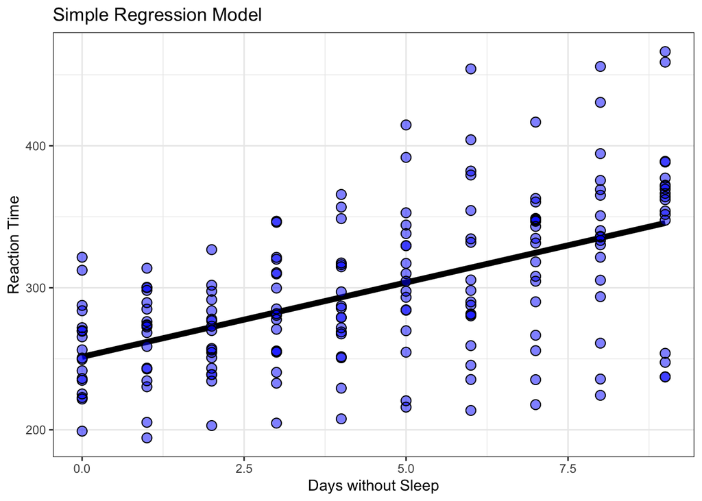

## 3. Add Random Intercepts

Now let’s fit a mixed-effects model to the same data. We’ll do two things.

1. Change *lm* to *lmer* to tell R that this is a mixed model, not a normal regression.

I’ve heard *lmer* pronounced as “elmer” or as “lemur”. Your choice, I guess. Are you a looney tunes Elmer Fudd fan or do you like king Julien from Madagascar?

2. We will add random intercepts for Subject.

In papers, you will see this referred to as “random by-Subject intercepts”.

```r
sleep.lmer <- lmer(Reaction ~ Days + (1 | Subject), data = sleepstudy)
```

Notice the format for including a random effect. The grouping variable (Subject) is encased in parentheses with a vertical bar - | - in front of it.

The 1 in front of the | represents the intercept. So the (1 | Subject) part of our formula means: *“use Subject as a random effect, and include by-subject intercepts (i.e. separate intercepts for each subject)”*.

How do the results of our mixed-effects model differ from the simple regression above?

Our regression model (above) fitted a single line to all the data points. But our mixed effect model is smarter; it knowns (because we told it) that the data points are nested within Subjects. This is represented in the graph below by the different colored points.

We also told the model to give each Subject their own intercept. Remember that a line has two properties:

- The slope, which represents the change in Y divided by the change in X (the rise over the run).
- The intercept, which represents the value of Y when X = 0.

In our model, we have fitted a separate regression line to each Subject. You can see these lines on the graph below. The lines all have the same slope (for now), but different intercepts; they cross the Y axis at different points.

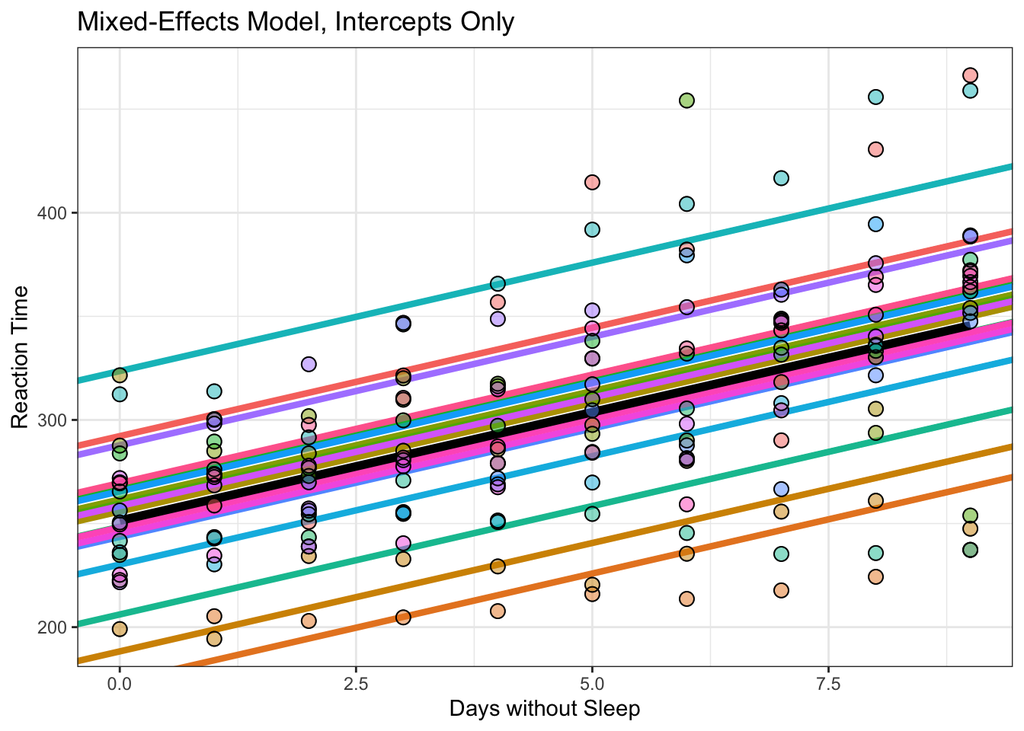

Take a moment and ask yourself: what does it mean that Subject 337 has a higher intercept than Subject 309?

#### What DOES it mean that Subject 337 has a higher intercept than Subject 309?

The intercept represents the value of Y (Reaction) when X (Days without sleep) equals 0. In other words, the intercept tells us what the subject’s reaction time was at day 0 - before they were deprived of sleep. People differ in their reaction time - some people are faster than other people. Adding random intercepts allows our model to account for this.

### Comparing mixed models to simple regression

What happens when we add these random intercepts? When we have one line for each group instead of just one line for all of the data, we can more closely match the lines to the data. In other words, we have less variance unexplained. Here are three ways to show you that this is true:

1. Residuals
2. AIC
3. R<sup>2</sup>

#### Residuals

You remember what residuals are: the difference in Y between the points and the lines. Let’s compare the regression residuals to the mixed model residuals:

```
## [1] "Regression Residuals"
```

```
##     Min.  1st Qu.   Median     Mean  3rd Qu.     Max.
## -110.848  -27.483    1.546    0.000   26.142  139.953
```

```
## [1] "Mixed Model Residuals"
```

```
##     Min.  1st Qu.   Median     Mean  3rd Qu.     Max.
## -3.22567 -0.55288  0.01085  0.00000  0.51880  4.25062
```

The Min and Max residuals are MUCH larger for regression than for the mixed model.

#### AIC

We talked previously about AIC, the Akaike Information Criterion. As you undoubtedly recall, the AIC is a measure of how much variance is left unaccounted for by the model. So, lower AIC is better. Let’s compare our models again:

| Regression | Mixed Model |
| --- | --- |
| 1906.2930564 | 1794.4650854 |

The AIC is smaller for the mixed model.

#### R<sup>2</sup>

And finally, R<sup>2</sup> is a measure that tells us how much variance we have accounted for with the model. In this sense, it is the opposite of the AIC: larger R<sup>2</sup> means a *better* model.

To get the R<sup>2</sup> for our mixed model, we need to load the MuMIn package. Add this code to your startup chunk:

```r
if(!require("MuMIn")) install.packages("MuMIn")
library(MuMIn)
```

And now to compare our models:

```r
r.squaredGLMM(sleep.regression)
```

```
##            R2m       R2c
## [1,] 0.2853276 0.2853276
```

```r
r.squaredGLMM(sleep.lmer)
```

```
##            R2m       R2c
## [1,] 0.2798856 0.7042555
```

Notice that the rsquared.GLMM() function gives us 2 R<sup>2</sup> values: R2m and R2c. R2m is the R<sup>2</sup> value for the *fixed effects only*. R2c is the R<sup>2</sup> value for the *fixed and random effects together*. Notice that these numbers are the same for the regression model, since there are no random effects in that model; all variance explained comes from the fixed effects.

Also notice that the R2c is a LOT bigger for the mixed model than for the regression; we’ve jumped from about 28% of the variance explained to more than 70% of the variance explained!

## 4. Add Random Slopes

Now let’s add random slopes to our model.

Random slopes allow the slope to vary for each Subject.

```r
sleep.lmer.slopes <- lmer(Reaction ~ Days + (1 + Days | Subject), data = sleepstudy)
```

Notice the syntax here. We started with random intercepts `(1 | Subject)`. Then we added in the variable Days that we had already included as a fixed effect: `(1 + Days | Subject)`.

[figure not shown]

As we have seen, a random intercept allows each Subject to have a different baseline level of the dependent variable (i.e. a different Reaction time).

Take a moment and ask yourself: what does it mean if Subject 337 has a steeper slope than Subject 309? What does that say about how 337 and 309 responded to sleep deprivation?

### What DOES having a different slope for each Subject represent?

A random slope allows each Subject to have a different response to a fixed effect. In other words, maybe some subjects handled the sleep deprivation better than others. Some subjects’ reaction time might have increased quickly over the days, indicating that they got slower more rapidly, a strong response to sleep deprivation. Other subjects’ reaction time increased more slowly, indicating that they were less affected by the sleep deprivation.

### Comparing Random Intercepts and Random Slopes

Here’s the AIC and R<sup>2</sup> for comparing the random intercepts model to the random slopes model (which also has random intercepts). What do these numbers tell us?

|  | Mixed Model - Random Intercepts ONLY | Mixed Model - Random Intercepts AND Slopes |
| --- | --- | --- |
| AIC | 1794.4650854 | 1755.628272 |
| R<sup>2</sup> | 0.7042555 | 0.7992199 |

30. Examine the made-up mixed-effects model below. Notice how the different parts of the model are numbered. Make a table like the one below and match the different numbered parts with the correct labels.

```r
fakemodel.lmer <- lmer(Number1 ~ 1 + Factor1 * Number2 + (1 + Factor1 * Number2 | Factor2), data = fakedata)
#                      _______   _   _______ _ _______    _   _______ _ _______   _______
#                         1      2      3    4   5        6      7    8   9         10
#                                _____________________    _______________________________
#                                          11                         12
```

| Label | Number(s) |
| --- | --- |
| Dependent Variable |  |
| Model Intercept |  |
| The Fixed Effects |  |
| A Fixed Effect |  |
| Interaction Term |  |
| The Random Effects |  |
| Random Intercept |  |
| Random Slopes |  |
| Nesting/Grouping Variable |  |

31. Imagine you were running the hypothetical model above. If you got a convergence error (“model failed to converge”) while running this model, what should you do? Show specifically how you would change the model before you tried running it again.

## Model Output

Here’s the output of our final sleep model:

```
## Linear mixed model fit by REML. t-tests use Satterthwaite's method ['lmerModLmerTest']
## Formula: Reaction ~ Days + (1 + Days | Subject)
##    Data: sleepstudy
##
## REML criterion at convergence: 1743.6
##
## Scaled residuals:
##     Min      1Q  Median      3Q     Max
## -3.9536 -0.4634  0.0231  0.4634  5.1793
##
## Random effects:
##  Groups   Name        Variance Std.Dev. Corr
##  Subject  (Intercept) 612.10   24.741
##           Days         35.07    5.922   0.07
##  Residual             654.94   25.592
## Number of obs: 180, groups:  Subject, 18
##
## Fixed effects:
##             Estimate Std. Error      df t value             Pr(>|t|)
## (Intercept)  251.405      6.825  17.000  36.838 < 0.0000000000000002 ***
## Days          10.467      1.546  17.000   6.771           0.00000326 ***
## ---
## Signif. codes:  0 '***' 0.001 '**' 0.01 '*' 0.05 '.' 0.1 ' ' 1
##
## Correlation of Fixed Effects:
##      (Intr)
## Days -0.138
```

So, let’s look at the output of this model more closely.

There are several different sections to our data:

- The first section describes the model, formula, and data
- The second section gives the REML criterion - how well does the model fit the data. This number isn’t really useful - it cannot be compared across models with different fixed effect structures. Other measures like AIC and R<sup>2</sup> are better.
- A summary of the residuals. This should be familiar from the regression output.
- A summary of the random effects. We can see the standard deviation for the random intercept, the random slope for Days, and the correlation between the two. We also see the standard deviation of the residuals - variance left unexplained even after considering the random effects.
- The Fixed Effects. This corresponds to the Coefficients portion of the regression output, and it the part we are most interested in.
- Correlation of fixed effects. This tells us which fixed effects were correlated. It can be useful for diagnosing collinearity, but otherwise just skip it.

The Fixed Effects section looks *almost* the same as a regression, with one additional column - df (degrees of freedom). This column and the *p*-values column P(<|t|) will only appear if you’ve loaded the lmerTest package. These columns can be interpreted in the same way as a regression.

### Model Levels

Even though the model was fitting multiple lines to the data, we only got one intercept and one slope for Days. Why?

Well, the model works in two stages, or levels (which is why it’s sometimes called a multilevel model).

- *Level 1*: individual data points. A line is fitted to the data points within each group.
- *Level 2*: groups. The intercepts and slopes for each group are averaged together to get an overall intercept and slope.

This distinction is a useful one, and can be applied to our fixed effects, too.

- Days is a Level 1 variable because it applies to the individual data points; data within a group (Subject) can have different values for Days.
- A variable such as Age would be a Level 2 variable because it applies to the groups, not to the individual data points. All data within a group would have the same value for Age, since Age applies to the grouping variable Subject.

### Practice Interpreting Model Results

You might want to review the parts of Unit 8 that deal with interpreting regression output, because it applies here, too!

#### Interpreting Mixed-Effects Model Output: Adopted IQ

Below is the output of a mixed-effects model. Use it to answer the questions below.

```
## Linear mixed model fit by REML. t-tests use Satterthwaite's method ['lmerModLmerTest']
## Formula: IQ ~ scale(Age, scale = FALSE) * scale(BirthMotherIQ, scale = FALSE) +
##     scale(AdoptedMotherEducation, scale = FALSE) + (1 + scale(Age,      scale = FALSE) | Child)
##    Data: AdoptedLong
##
## REML criterion at convergence: 1909.4
##
## Scaled residuals:
##      Min       1Q   Median       3Q      Max
## -2.23226 -0.54017 -0.01727  0.55784  2.17314
##
## Random effects:
##  Groups   Name                      Variance Std.Dev. Corr
##  Child    (Intercept)               97.9046  9.895
##           scale(Age, scale = FALSE)  0.9901  0.995    0.21
##  Residual                           65.4727  8.092
## Number of obs: 248, groups:  Child, 62
##
## Fixed effects:
##                                                                Estimate Std. Error        df t value             Pr(>|t|)
## (Intercept)                                                   112.16935    1.35761  59.03396  82.623 < 0.0000000000000002 ***
## scale(Age, scale = FALSE)                                      -0.69634    0.17577  60.00085  -3.962              0.00020 ***
## scale(BirthMotherIQ, scale = FALSE)                             0.23492    0.08591  59.04423   2.735              0.00823 **
## scale(AdoptedMotherEducation, scale = FALSE)                   -0.17561    0.46755  58.99999  -0.376              0.70856
## scale(Age, scale = FALSE):scale(BirthMotherIQ, scale = FALSE)   0.02683    0.01110  60.00085   2.418              0.01864 *
## ---
## Signif. codes:  0 '***' 0.001 '**' 0.01 '*' 0.05 '.' 0.1 ' ' 1
##
## Correlation of Fixed Effects:
##             (Intr) s(A,s=F s(Bs=F s(AMs=F
## s(A,s=FALSE  0.136
## s(BMIQ,s=FA  0.000  0.000
## s(AME,s=FAL  0.000  0.000  -0.070
## s(A,s=FAs=F  0.000  0.000   0.136  0.000
```

32. What was the dependent variable?
33. List the fixed effect(s)
34. Describe the random effects structure. What was the nesting variable? Were there random by-nesting-variable intercepts? What about random slopes?
35. How many observations were there in this data set?
36. How many different levels of the nesting variable were there?
37. Which of the following best describes the Intercept in this model? The intercept represents the value of IQ when…
    - Age is 0
    - Age, BirthMotherIQ, and AdoptedMotherEducation are 0
    - Age is the average age
    - Age, BirthMotherIQ, and AdoptedMotherEducation are all their average values
38. What influence, if any, does Age have on IQ?
39. What influence, if any, does BirthMotherIQ have on IQ of the child?
40. What influence, if any, does AdoptedMotherEducation have on IQ of the child?
41. Which of the following statements best captures the significant interaction of Age and BirthMotherIQ
    - The higher the birth mother’s IQ, the stronger the effects of age on child IQ.
    - As these adopted children aged, their IQ tended to go down, but this effect was weaker for children with high-IQ birth mothers.
    - As the adopted children aged, their birth mother’s IQ has less influence on the child’s IQ.

#### Interpreting Mixed-Effects Model Output: Visual or Verbal?

Below is the output of a mixed-effects model. Use it to answer the questions below.

```
## Linear mixed model fit by REML. t-tests use Satterthwaite's method ['lmerModLmerTest']
## Formula: Time ~ Task + Report + (1 | Subject) + Task:Report
##    Data: VisualVerbal
##
## REML criterion at convergence: 453.8
##
## Scaled residuals:
##     Min      1Q  Median      3Q     Max
## -1.6542 -0.6052 -0.2229  0.5057  2.4782
##
## Random effects:
##  Groups   Name        Variance Std.Dev.
##  Subject  (Intercept)  8.291   2.879
##  Residual             14.559   3.816
## Number of obs: 80, groups:  Subject, 20
##
## Fixed effects:
##                         Estimate Std. Error     df t value             Pr(>|t|)
## (Intercept)               12.850      1.069 54.483  12.022 < 0.0000000000000002 ***
## TaskVisual                -3.837      1.207 57.000  -3.180              0.00238 **
## ReportVisual               0.839      1.207 57.000   0.695              0.48967
## TaskVisual:ReportVisual    8.322      1.706 57.000   4.877           0.00000902 ***
## ---
## Signif. codes:  0 '***' 0.001 '**' 0.01 '*' 0.05 '.' 0.1 ' ' 1
##
## Correlation of Fixed Effects:
##             (Intr) TskVsl RprtVs
## TaskVisual  -0.564
## ReportVisul -0.564  0.500
## TskVsl:RprV  0.399 -0.707 -0.707
```

43. What was the dependent variable?
44. List the fixed effect(s)
45. Describe the random effects structure. What was the nesting variable? Were there random by-nesting varable intercepts? What about random slopes?
46. How many observations were there in this data set?
47. How many different levels of the nesting variable were there?
48. The Task variable has 2 levels: Verbal and Visual. The Report variable also has 2 levels: Verbal and Visual. What was the ‘baseline’ level for each of these variables?
49. Which of the following combinations does the Intercept show the Time for?
    - Task Visual and Report Visual
    - Task Verbal and Report Visual
    - Task Visual and Report Verbal
    - Task Verbal and Report Verbal
50. What does the effect of Task say about the Time difference between Verbal and Visual tasks? Does this result apply to all Report levels, or just one? If just one, which one?
51. What does the effect of Report say about the Time difference between Verbal and Visual response methods? Does this result apply to all Report levels, or just one? If just one, which one?
52. (Bonus) Which of the following graphs (1, 2, 3, or 4) best represents the results of the mixed-effects model shown above?

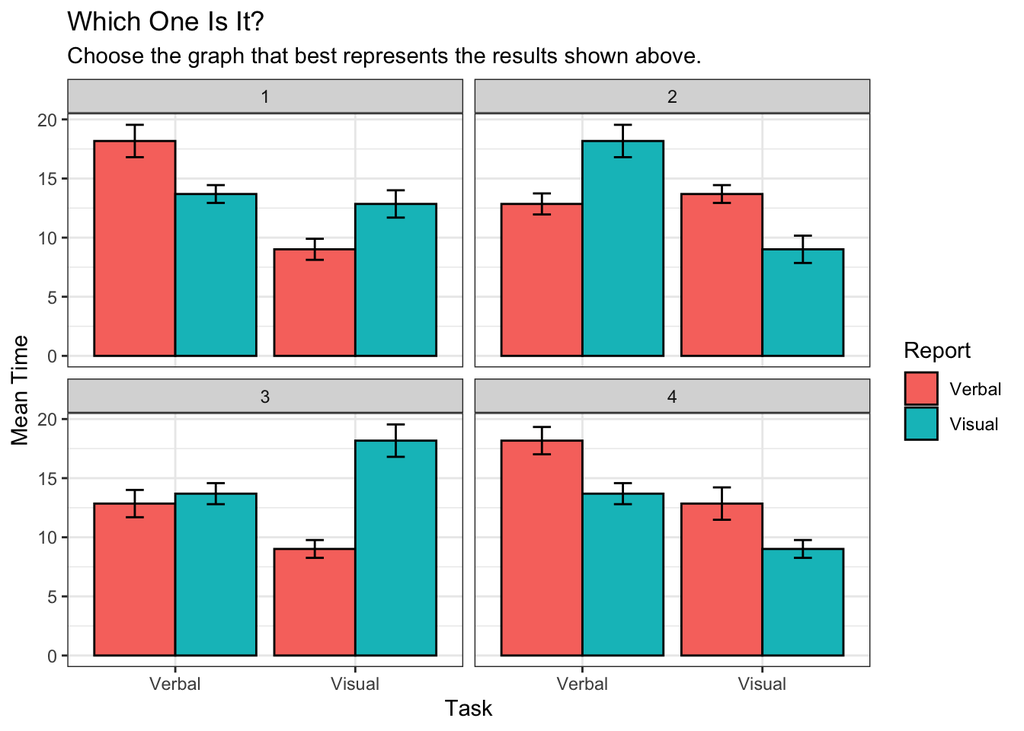

# Evaluating Your Model

Most of what you learned about evaluating regression models applies here as well. You still need to:

1. Fit Your Model, removing parameters that don’t contribute to the model
2. Check for (and fix) collinearity
3. Assess Model Fit

Thee steps are *similar* to what we did for regression, but we have to do them a bit differently.

## Fit Your Model

We can’t just use the *step()* function to fit lmers, UNLESS we have loaded the *lmerTest* package. This is where the *lmerTest* package comes in handy again. The *step()* function tests all your random effects to see if they should be retained in the model. It then tests all of your fixed effects. We nest the *step()* function inside the *get_model()* function in order to pull out and save the final version of the model that *step()* decides on.

**Nerdy aside**: What the step function is doing is using Likelihood Ratio Tests to compare a model with each random or fixed effect to a model without that random or fixed effect, to see if the overall model fit is better with that effect in. If the model isn’t improved by this effect, it is removed. This is one way to fit mixed-effects models, but it isn’t the only way! In fact, this is another area of debate on how to properly use mixed-effects models. For now, just report that you used the step() function from lmerTest to fit your model, and be prepared to adopt new best practices in the future - if everyone ever comes to an agreement on what those best practices are.

```r
sleep.lmer.step <- get_model(step(sleep.lmer.slopes))
summary(sleep.lmer.step)
```

```
## Linear mixed model fit by REML. t-tests use Satterthwaite's method ['lmerModLmerTest']
## Formula: Reaction ~ Days + (1 + Days | Subject)
##    Data: sleepstudy
##
## REML criterion at convergence: 1743.6
##
## Scaled residuals:
##     Min      1Q  Median      3Q     Max
## -3.9536 -0.4634  0.0231  0.4634  5.1793
##
## Random effects:
##  Groups   Name        Variance Std.Dev. Corr
##  Subject  (Intercept) 612.10   24.741
##           Days         35.07    5.922   0.07
##  Residual             654.94   25.592
## Number of obs: 180, groups:  Subject, 18
##
## Fixed effects:
##             Estimate Std. Error      df t value             Pr(>|t|)
## (Intercept)  251.405      6.825  17.000  36.838 < 0.0000000000000002 ***
## Days          10.467      1.546  17.000   6.771           0.00000326 ***
## ---
## Signif. codes:  0 '***' 0.001 '**' 0.01 '*' 0.05 '.' 0.1 ' ' 1
##
## Correlation of Fixed Effects:
##      (Intr)
## Days -0.138
```

Looks like we want the random slopes and intercept. And we’re keeping Days as a fixed effect, too. We saw above that all of these parameters improved the model fit, so we shouldn’t be surprised at this outcome.

## Check for collinearity

We can check for collinearity the same way we did for regression: with the *vif* function.

```r
vif(sleep.lmer.step)
```

We get an error here because there is only 1 fixed effect. There cannot be any collinearity between variables when there is only one variable!

## Assess Model Fit

As noted above, to get the R<sup>2</sup> for our mixed model, we need to load the MuMIn package. Add this code to your startup chunk:

```r
if(!require("MuMIn")) install.packages("MuMIn")
library(MuMIn)
```

And now get the R<sup>2</sup>:

```r
r.squaredGLMM(sleep.lmer.step)
```

```
##            R2m       R2c
## [1,] 0.2786511 0.7992199
```

Remember, 0.278 is the R<sup>2</sup> of the fixed effects only - this is **not** what we want. 0.799 is the R<sup>2</sup> including the random effects, so this is the number we will report.

Let’s evaluate the fit of our model on the Visual or Verbal data above.

53. Below is the colinearity info from the *vif* function. What do these numbers tell you?

```r
vif(wordmemory.lmer)
```

```
##        Task      Report Task:Report
##           2           2           3
```

54. Complete the following sentences:

The R<sup>2</sup> for the final model was _____. The fixed effects account for about _____ of variance in the model, while other unmeasured differences between participants account for the rest, up to _____ total.

```r
r.squaredGLMM(wordmemory.lmer)
```

```
##           R2m       R2c
## [1,] 0.319717 0.5665432
```

# Describing Mixed Model Results

Now that you have finalized your mixed-effects model, its time to report the results. We need to report information for the model as a whole, as well as the individual predictors:

Model as a Whole:

- What was the dependent variable?
- What were the fixed effects
  - What transformations (such as centering) were applied?
  - What interactions were included?
- What were the random effects?
- How was model fitting accomplished?
  - What fixed effects and/or interactions were discarded during model fitting?
  - What random effects were discarded during model fitting
- How well does the final model fit the data?
- Report AIC and/or R2c.

For each predictor and interaction, we need to report the following:

- The estimate
- The standard error
- The t value.
- the p value.
- A plain-language description of the interpretation.

Here’s how we might describe our results:

> A mixed-effects model was fitted to the data, with Reaction time as the dependent variable. The model included Days of sleep deprivation as a fixed effect. Random by-Subject intercepts were included in the model, as were random by-Subject slopes for Days. The fixed and random effects structure were fitted using the step() function from the lmerTest package. All fixed and random effects were retained. The R<sup>2</sup> for the final model was 0.799.

And now to describe the individual results:

> The effect of Days was significant (Estimate = 10.47, *SE* = 1.55, *t* = 6.77, *p* < .001), indicating that for each day of sleep deprivation, reaction time increased by about 10 milliseconds on average.
55. Complete the following paragraph to describe the Adopted IQ data results above.

> A mixed-effects model was fitted to the data, with _____ as the dependent variable. The model included _____, _____, and _____ as fixed effects, as well as the interaction of _____ and _____. Continuous fixed effects were centered. Random by-Child intercepts were included in the model, as were random by-Child slopes for _____. The fixed and random effects structure were fitted using the step() function from the lmerTest package. All fixed and random effects were retained. The R<sup>2</sup> for the final model was 0.68.

And now to describe the individual results:

# Some More Step-by-Step Examples

## Vocab Growth

Let’s start with the VocabGrowth data set. We’ll include the following variables

- *Dependent Variable*: Vocab_Score, a number representing a child’s vocabulary
- *Predictor 1*: Grade, a number representing the child’s current grade level
- *Random Effect 1*: Student, a factor representing which participant the data came from

We’ll start with a ‘maximal’ model that includes all possible random slopes as well as a random intercept and a fixed effect for Grade.

```r
LongVocabGrowth <- VocabGrowth %>% mutate(Student = row.names(.)) %>% relocate(Student) %>%
  pivot_longer(cols = 2:ncol(.), names_to = c("Grade"), values_to = "Vocab_Score") %>% mutate(Grade = gsub("grade", "", Grade), Grade = as.numeric(Grade))

vocab.lmer <- lmer(Vocab_Score ~ scale(Grade, scale = FALSE) + (1 + scale(Grade, scale = FALSE) |Student), data = LongVocabGrowth)
```

```
## boundary (singular) fit: see help('isSingular')
```

### Fitting the Model

It looks like there were some convergence problems with this model, so let’s use the step() function to fit it.

```r
vocab.lmer <-get_model(step(vocab.lmer))
summary(vocab.lmer)
```

```
## Linear mixed model fit by REML. t-tests use Satterthwaite's method ['lmerModLmerTest']
## Formula: Vocab_Score ~ scale(Grade, scale = FALSE) + (1 | Student)
##    Data: LongVocabGrowth
##
## REML criterion at convergence: 877.7
##
## Scaled residuals:
##      Min       1Q   Median       3Q      Max
## -2.33435 -0.65027 -0.03089  0.63865  2.64842
##
## Random effects:
##  Groups   Name        Variance Std.Dev.
##  Student  (Intercept) 3.2432   1.8009
##  Residual             0.9001   0.9487
## Number of obs: 256, groups:  Student, 64
##
## Fixed effects:
##                              Estimate Std. Error        df t value             Pr(>|t|)
## (Intercept)                   2.53406    0.23279  63.00000   10.89 0.000000000000000412 ***
## scale(Grade, scale = FALSE)   0.74403    0.05304 191.00000   14.03 < 0.0000000000000002 ***
## ---
## Signif. codes:  0 '***' 0.001 '**' 0.01 '*' 0.05 '.' 0.1 ' ' 1
##
## Correlation of Fixed Effects:
##             (Intr)
## s(G,s=FALSE 0.000
```

It looks like we didn’t need the random slope for *Grade*.

### Checking for Collinearity

There’s only the one fixed effect, so no opportunity for collinearity. We’ll skip this step.

### Assessing Model Fit

And now to assess the model fit.

```r
AIC(vocab.lmer)
```

```
## [1] 885.7167
```

```r
r.squaredGLMM(vocab.lmer)
```

```
##            R2m      R2c
## [1,] 0.1435918 0.813951
```

R2c is 0.81, but R2m is only 0.14. This means that Grade accounts for about 14% of variance in how many words a child knows, while other unmeasured differences between children account for the rest, up to 81% total.

### Describing the Results

Here’s how we might describe our results:

> A mixed-effects model was fitted to the data, with vocabulary score as the dependent variable. The model included Grade as a continuous fixed effect, and random by-Student intercepts were also included in the model, but no random slopes were included as they prevented the model from converging. The fixed and random effects structure were fitted using the step() function from the lmerTest package. The R<sup>2</sup> for the final model was 0.81.

And now to describe the individual results:

> The effect of Grade was significant (Estimate = 0.74, *SE* = 0.053, *t* = 14.03, *p* < .001), indicating that as the children progressed from one grade to the next, their vocabulary score increased by 0.74 points.

## Reaction Time

Now let’s look at the ReactTime data set. We’ll include the following variables

- *Dependent Variable*: ReactTime, a number representing a participants speed to react the the stimulus
- *Fixed Effect 1*: Angle, how much the stimulus was tilted
- *Fixed Effect 2*: Noise, whether some visual ‘noise’ was present to make it harder to see the stimulus
- *Fixed Effect 3*: The interaction of Angle and Noise counts as a separate fixed effect.
- *Random Effect 1*: Subject, a factor representing which participant the data came from

```r
LongReactData <- ReactTime %>% mutate(Subject = row.names(.)) %>% relocate(Subject) %>%
  pivot_longer(cols = 2:ncol(.), names_to = c("Angle", "Noise"), names_sep = "N", values_to = "Reaction_Time") %>%
  mutate(Noise = case_when(
    Noise == "A" ~ "Absent",
    Noise == "P" ~ "Present",
    TRUE ~ NA
  ), Angle = gsub("deg", "", Angle), Angle = as.numeric(Angle))

react.lmer <- lmer(Reaction_Time ~ 1 + Angle * Noise + (1 + Angle * Noise |Subject), data = LongReactData)
```

```
## boundary (singular) fit: see help('isSingular')
```

### Fitting the Model

It looks like there were some convergence problems with this model, so let’s use the step() function to fit it.

```r
react.lmer <-get_model(step(react.lmer))
summary(react.lmer)
```

```
## Linear mixed model fit by REML. t-tests use Satterthwaite's method ['lmerModLmerTest']
## Formula: Reaction_Time ~ Angle + Noise + (Noise | Subject) + Angle:Noise
##    Data: LongReactData
##
## REML criterion at convergence: 646.4
##
## Scaled residuals:
##      Min       1Q   Median       3Q      Max
## -1.87353 -0.66222 -0.03909  0.53797  2.21126
##
## Random effects:
##  Groups   Name         Variance Std.Dev. Corr
##  Subject  (Intercept)  3267     57.16
##           NoisePresent 3996     63.21    0.20
##  Residual              2466     49.66
## Number of obs: 60, groups:  Subject, 10
##
## Fixed effects:
##                    Estimate Std. Error      df t value        Pr(>|t|)
## (Intercept)         467.000     23.070  14.926  20.243 0.0000000000029 ***
## Angle                 8.250      2.776  38.000   2.972         0.00511 **
## NoisePresent         36.000     28.472  17.787   1.264         0.22240
## Angle:NoisePresent   25.500      3.926  38.000   6.495 0.0000001195483 ***
## ---
## Signif. codes:  0 '***' 0.001 '**' 0.01 '*' 0.05 '.' 0.1 ' ' 1
##
## Correlation of Fixed Effects:
##             (Intr) Angle  NsPrsn
## Angle       -0.481
## NoisePresnt -0.201  0.390
## Angl:NsPrsn  0.340 -0.707 -0.552
```

### Checking for Collinearity

Now let’s check for collinearity. This should be familiar.

```r
vif(react.lmer)
```

```
##       Angle       Noise Angle:Noise
##    2.000000    1.437294    2.437294
```

No collinearity, that’s good.

### Assessing Model Fit

And now to assess the model fit.

```r
AIC(react.lmer)
```

```
## [1] 662.4134
```

```r
r.squaredGLMM(react.lmer)
```

```
##           R2m      R2c
## [1,] 0.573657 0.875771
```

R2c is 0.88, which is pretty good!

### Describing the Results

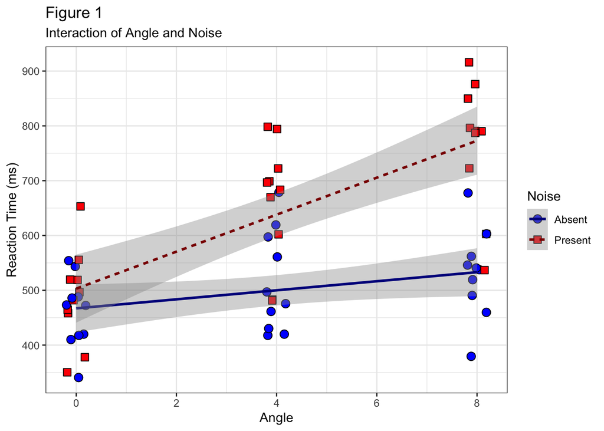

## IQ

Let’s try this again!

For this example, we’ll use the *bdf* data set from the *mlmRev* package. This data has demographic data and IQ scores for 2,287 elementary school students from the Netherlands.

```r
if(!require("mlmRev")) install.packages("mlmRev")
library(mlmRev)
```

- *Dependent Variable*: langPOST, a number representing scores on a language test
- *Predictor 1*: IQ.perf, a number representing overall IQ scores
- *Predictor 2*: IQ.verb, a number representing verbal IQ scores
- *Predictor 3*: sex (Levels: 0, 1, who knows which is which)
- *Predictor 4*: Minority (Levels: Y, N)
- *Predictor 5*: ses, a number representing the student’s socio-economic status
- *Predictor 6*: schoolSES, a number representing the school’s overall SES
- *Random Effect*: SchoolNR, a factor representing the school the student attends

```r
dutch.language <- lmer(langPOST ~ IQ.perf + IQ.verb + sex + Minority + ses + schoolSES + (1 + IQ.perf + IQ.verb + sex + Minority + ses + schoolSES| schoolNR), data = bdf)
```

```
## boundary (singular) fit: see help('isSingular')
```

### Fitting the model

Let’s start by removing any unnecessary effects:

```r
dutch.language.step <-get_model(step(dutch.language))
summary(dutch.language.step)
```

```
## Linear mixed model fit by REML. t-tests use Satterthwaite's method ['lmerModLmerTest']
## Formula: langPOST ~ IQ.perf + IQ.verb + sex + ses + (IQ.perf + IQ.verb |      schoolNR)
##    Data: bdf
##
## REML criterion at convergence: 14905.2
##
## Scaled residuals:
##     Min      1Q  Median      3Q     Max
## -4.3295 -0.6212  0.0680  0.6917  3.2735
##
## Random effects:
##  Groups   Name        Variance Std.Dev. Corr
##  schoolNR (Intercept) 63.43956 7.9649
##           IQ.perf      0.03716 0.1928   -0.83
##           IQ.verb      0.12828 0.3582   -0.83  0.38
##  Residual             35.67126 5.9725
## Number of obs: 2287, groups:  schoolNR, 131
##
## Fixed effects:
##               Estimate Std. Error         df t value             Pr(>|t|)
## (Intercept)    3.79869    1.13571  135.73361   3.345              0.00107 **
## IQ.perf        0.73733    0.06808  675.89285  10.830 < 0.0000000000000002 ***
## IQ.verb        1.99911    0.08066  138.35460  24.784 < 0.0000000000000002 ***
## sex1           2.95310    0.25868 2194.75340  11.416 < 0.0000000000000002 ***
## ses            0.13585    0.01399 2084.93582   9.709 < 0.0000000000000002 ***
## ---
## Signif. codes:  0 '***' 0.001 '**' 0.01 '*' 0.05 '.' 0.1 ' ' 1
##
## Correlation of Fixed Effects:
##         (Intr) IQ.prf IQ.vrb sex1
## IQ.perf -0.439
## IQ.verb -0.624 -0.293
## sex1    -0.148  0.107 -0.018
## ses     -0.080 -0.128 -0.201 -0.045
## optimizer (nloptwrap) convergence code: 0 (OK)
## Model failed to converge with max|grad| = 0.180002 (tol = 0.002, component 1)
```

```r
dutch.language.noslopes <- lmer(langPOST ~ IQ.perf + IQ.verb + sex + ses + (1 | schoolNR), data = bdf)
```

```
## [1] "With Slopes"
```

```
##            R2m       R2c
## [1,] 0.4335373 0.5504504
```

```
## [1] "No Slopes"
```

```
##            R2m       R2c
## [1,] 0.4295047 0.5394263
```

Because these last 2 random slopes do almost nothing to help our model, and because errors make us nervous and distrustful, we’ll remove these slopes. Here is our final model:

```r
dutch.language <- lmer(langPOST ~ IQ.perf + IQ.verb + sex + ses + (1 | schoolNR), data = bdf)
summary(dutch.language)
```

```
## Linear mixed model fit by REML. t-tests use Satterthwaite's method ['lmerModLmerTest']
## Formula: langPOST ~ IQ.perf + IQ.verb + sex + ses + (1 | schoolNR)
##    Data: bdf
##
## REML criterion at convergence: 14932.4
##
## Scaled residuals:
##     Min      1Q  Median      3Q     Max
## -4.1771 -0.6202  0.0687  0.6811  3.7961
##
## Random effects:
##  Groups   Name        Variance Std.Dev.
##  schoolNR (Intercept)  8.702   2.950
##  Residual             36.461   6.038
## Number of obs: 2287, groups:  schoolNR, 131
##
## Fixed effects:
##               Estimate Std. Error         df t value             Pr(>|t|)
## (Intercept)    4.03960    0.92232 2050.98951   4.380            0.0000125 ***
## IQ.perf        0.72340    0.06651 2220.66785  10.876 < 0.0000000000000002 ***
## IQ.verb        1.97209    0.07340 2251.70948  26.869 < 0.0000000000000002 ***
## sex1           2.96875    0.26057 2202.17773  11.393 < 0.0000000000000002 ***
## ses            0.14132    0.01425 2256.39241   9.914 < 0.0000000000000002 ***
## ---
## Signif. codes:  0 '***' 0.001 '**' 0.01 '*' 0.05 '.' 0.1 ' ' 1
##
## Correlation of Fixed Effects:
##         (Intr) IQ.prf IQ.vrb sex1
## IQ.perf -0.405
## IQ.verb -0.545 -0.371
## sex1    -0.186  0.114 -0.021
## ses     -0.106 -0.129 -0.222 -0.043
```

### Checking Collinearity

```r
vif(dutch.language.step)
```

```
##  IQ.perf  IQ.verb      sex      ses
## 1.151073 1.168325 1.012679 1.086538
```

No sign of collinearity problems here.

### Assessing Model Fit

```r
AIC(dutch.language.step)
```

```
## [1] 14929.23
```

```r
r.squaredGLMM(dutch.language)
```

```
##            R2m       R2c
## [1,] 0.4295047 0.5394263
```

### Describing the Results

And now to describe the individual results:

> The effect of overall IQ was significant (Estimate = 0.72, *SE* = 0.067, *t* = 10.88, *p* < .001), indicating that for each point increase in overall IQ, language score increased by 0.7. Verbal IQ also separately predicted language score (Estimate = 1.97, *SE* = 0.073, *t* = 26.87, *p* < .001), indicating that language scores went up almost 2 points for each point increase in verbal IQ. Sex was also predictive of language skill (Estimate = 2.97, *SE* = 0.26, *t* = 11.39, *p* < .001) indicating that whichever sex was originally coded as 1 scores about 3 points higher on the language test. Finally, SES was predictive of language score (Estimate = 0.14, *SE* = 0.014, *t* = 9.91, *p* < .001), indicating that for each unit increase in SES, langauge scores went up by 0.14 points.

## Flights

Let’s finish up with our familiar *flights* data from the *nycflights13* package. We’ll include the following variables

- *Dependent Variable*: Arrival delay (arr_delay), a number representing how late the flight was to arrive at its destination
- *Predictor 1*: Departure delay (dep_delay), a number representing how late the flight was leaving
- *Predictor 2*: Scheduled arrival time (sched_arr_time), a number representing when the flight was expected to arrive; larger numbers mean later flights.
- *Predictor 3*: Origin, the airport the flight left from (Levels: EWA, LGA, JFK)
- *Predictor 4*: Air time (air_time), a number representing how many minutes the flight was in the air.
- *Random Effect 1*: Carrier, a factor representing which airline operated the flight
- *Random Effect 2*: Destination (dest), a factor representing the airport the flight was going to.

Before we start, let’s consider Origin. We are putting it in as a fixed effect. However, we could have easily made it a random effect, since the flights were definitely grouped by which airport they left from. Why make it a fixed effect instead of a random one? It depends entirely on our goals. If we care about origin and want to know which of the three NYC airports tends to have later-arriving flights, we need to test this by including origin as a fixed effect. On the other hand, if we don’t really care about testing the origin variable but we want to control for it, then we should make it a random effect; this is exactly what we have done for carrier and destination.

### Fitting the Model

Normally, we would start with a full or ‘maximal’ model that includes all our fixed effects, two grouping factors (carrier, which means the airline, and dest, which means the flight’s destination), and all possible random slopes. However, in this case such a model would take *forever* to run! So this time we will start with no random slopes.

```r
library(nycflights13)
flights.lmer <- lmer(arr_delay ~ dep_delay + sched_arr_time + origin + air_time + (1 | carrier) + (1 | dest), data = flights)
```

Even this one takes a while to run.

#### Fitting the Model

Now we can add the random slopes one at a time and test the model to see if that slope should remain in the model. I’ve done this for you. It took a while.

Spoiler alert: we don’t need *any* random slopes in this model.

Now let’s see if we need any fixed effects:

```r
flights.lmer <-get_model(step(flights.lmer))
summary(flights.lmer)
```

```
## Linear mixed model fit by REML. t-tests use Satterthwaite's method ['lmerModLmerTest']
## Formula: arr_delay ~ dep_delay + sched_arr_time + origin + air_time +      (1 | carrier) + (1 | dest)
##    Data: flights
##
## REML criterion at convergence: 2697372
##
## Scaled residuals:
##     Min      1Q  Median      3Q     Max
## -7.6765 -0.6125 -0.1346  0.4310 13.6753
##
## Random effects:
##  Groups   Name        Variance Std.Dev.
##  dest     (Intercept) 7621.92  87.304
##  carrier  (Intercept)   20.38   4.514
##  Residual              221.09  14.869
## Number of obs: 327346, groups:  dest, 104; carrier, 16
##
## Fixed effects:
##                      Estimate     Std. Error             df t value            Pr(>|t|)
## (Intercept)      -130.1633198      8.6461716    106.5011849  -15.05 <0.0000000000000002 ***
## dep_delay           1.0242229      0.0006622 327226.0469838 1546.57 <0.0000000000000002 ***
## sched_arr_time     -0.0009117      0.0000555 327239.5793383  -16.43 <0.0000000000000002 ***
## originJFK          -2.8379873      0.0962533 324060.0595506  -29.48 <0.0000000000000002 ***
## originLGA          -1.4571503      0.0846775 326180.4281903  -17.21 <0.0000000000000002 ***
## air_time            0.8024365      0.0021886 327140.1566755  366.64 <0.0000000000000002 ***
## ---
## Signif. codes:  0 '***' 0.001 '**' 0.01 '*' 0.05 '.' 0.1 ' ' 1
##
## Correlation of Fixed Effects:
##             (Intr) dp_dly schd__ orgJFK orgLGA
## dep_delay    0.000
## sched_rr_tm -0.010 -0.162
## originJFK   -0.004  0.002 -0.022
## originLGA   -0.005  0.013 -0.001  0.548
## air_time    -0.040  0.017 -0.014 -0.046 -0.029
```

The final model includes all fixed effects AND random intercepts, but no random slopes.

### Checking for Collinearity

Now let’s check for collinearity. This should be familiar.

```r
vif(flights.lmer)
```

```
##                    GVIF Df GVIF^(1/(2*Df))
## dep_delay      1.027608  1        1.013710
## sched_arr_time 1.028011  1        1.013909
## origin         1.003189  2        1.000796
## air_time       1.002621  1        1.001310
```

No sign of collinearity here. Yay!

### Assessing Model Fit

And now to assess the model fit.

```r
AIC(flights.lmer)
```

```
## [1] 2697390
```

```r
r.squaredGLMM(flights.lmer)
```

```
##            R2m       R2c
## [1,] 0.4770339 0.9852962
```

R2c is 0.985! We’ve almost perfectly accounted for arrival delays. No wonder adding the random slopes wasn’t necessary to improve model fit - we didn’t have any room to improve.

### Describing the Results

Here’s how we might describe our results:

> A mixed-effects model was fitted to the data, with arrival delay as the dependent variable. The model included three continuous fixed effects - departure delay, scheduled arrival time, and air time - as well as origin, a factor representing which airport the flight had departed from (EWR, LGA, or JFK). Random by-Carrier and by-Destination intercepts were included in the model, but no random slopes were included as they prevented the model from converging. The fixed and random effects structure were fitted using the step() function from the lmerTest package. All fixed effects and random intercepts were included in the final model. The R<sup>2</sup> for the final model was 0.985.

# Practice Running Mixed-Effects Models

To actually run a mixed-effects model you will need the packages “lme4” and “lmerTest”. Add this code to your Setup Chunk:

```r
if(!require("lme4")) install.packages("lme4")
library(lme4)
if(!require("lmerTest")) install.packages("lmerTest")
library(lmerTest)
```

## Finger Tapping

For this example, you’ll need to load the *Stat2Data* package.

Add this code to your setup chunk:

```r
if (!require("Stat2Data")) install.packages("Stat2Data")
library(Stat2Data)
```

56. Run the following code, and examine the data. Examine the 3 variables (use the help page to guide you) and assign them to the table below:

```r
data(Fingers)
?Fingers
Fingers
```

|  | Variable |
| --- | --- |
| Dependent Variable |  |
| Fixed Effect |  |
| Random Effect |  |

57. Based on your decisions in *#56*, set up a mixed-effects model with that dependent variable, fixed effect(s), and random effect(s). Add any random slopes as appropriate.
58. Run the model, using the step() and get_model() functions to fit the model and get the final result.
59. Check for collinearity and get the R<sup>2</sup> for the model.
60. Write a brief APA-style paragraph describing the results.

## Self Esteem

For this example, you’ll need to load the *datarium* package.

Add this code to your setup chunk:

```r
if (!require("datarium")) install.packages("datarium")
library(datarium)
```

61. Run the following code, and examine the data. Then do the following
    - Now pivot the data, names to *time* and values to *self_esteem_score*
    - mutate time, using *gsub()* to remove the ’t’s
    - mutate time to a number

    In the end, the data should look like this:

```r
data(selfesteem2)
?selfesteem2
selfesteem2
```

```
## # A tibble: 6 × 4
##   id    treatment  time self_esteem_score
##   <fct> <fct>     <dbl>             <dbl>
## 1 1     ctr           1                83
## 2 1     ctr           2                77
## 3 1     ctr           3                69
## 4 2     ctr           1                97
## 5 2     ctr           2                95
## 6 2     ctr           3                88
```

62. Examine the variables listed below (use the help page to guide you) and assign them to the table below:
    - id
    - treatment
    - time
    - self_esteem_score

|  | Variable |
| --- | --- |
| Dependent Variable |  |
| Fixed Effect |  |
| Random Effect |  |

63. Based on your decisions in *#62*, set up a mixed-effects model with that dependent variable, fixed effect(s), and random effect(s). Add any random slopes as appropriate.
64. Run the model, using the step() and get_model() functions to fit the model and get the final result.
65. Check for collinearity and get the R<sup>2</sup> for the model.
66. Write a brief APA-style paragraph describing the results.

## Real Data: Reading, Lyrics, and the Sound of Silence

For this analysis, you’ll be using data from a reading study:

Vasilev, M. R., Hitching, L., & Tyrrell, S. (2023). What makes background music distracting? Investigating the role of song lyrics using self-paced reading. *Journal of Cognitive Psychology*, 1-27.

The OSF page is here: https://osf.io/8zw4x/ The specific data we will use is here: https://osf.io/7y3v9

This study tested people’s reading rates under 3 conditions:

- Silence
- Lyrical Music
- Instrumental Music

The goal of the study was to test whether background music affected how quickly people read, and whether it matters whether the music had lyrics or not.

You may recognize this as an example I used earlier in the ANOVA unit. Now it’s your turn!

67. Download the file “read_rate_data.csv” to your R project folder. Then write a pipe that does the following:
    - Read in the data as *readingratedata*.
    - mutate *subject* into a factor
    - create a new variable *subjectALL* that is the combination of *subject* and *Experiment*
    - filter the data so that the *sound* variable does NOT include the level ‘speech’.
68. Examine the variables listed below and assign them to the table below:
    - item
    - sound
    - wpm (words per minute)
    - Experiment
    - subjectALL

    Ignore all the other columns.

|  | Variable |
| --- | --- |
| Dependent Variable |  |
| Fixed Effect |  |
| Random Effect |  |

69. Based on your decisions in *#68*, set up a mixed-effects model with that dependent variable, fixed effect(s), and random effect(s). Add any random slopes as appropriate.
70. Run the model, using the step() and get_model() functions to fit the model and get the final result.
71. Check for collinearity and get the R<sup>2</sup> for the model.
72. Write a brief APA-style paragraph describing the results.

# Real Data: Marriage and Other Disasters (Bonus)

Test the following research questions using a mixed-effects model. * How does perceived social support influence relationship satisfaction? * How does perceived stress influence relationship satisfaction? * Do the effects of these predictors differ for husbands and wives? * Do these effects hold if time is included as a co-variate?

The codebook for this study is at https://osf.io/auxzt

To do this, do the following. * Read in ‘marriagedata.csv’ from Checklist 4. * Set up your mixed-effects model, following the steps below. * Run the model and report the results.

73. Starting with the regression model from Checklist 8, item 68, set up a mixed-effects model. Show your code. You’ll need to add *time* as a covariate and add the random effects structure. Some questions to guide you:
    - Is a co-variate a random or fixed effect? What was it for a regression?
    - What is the nesting variable here?
    - Which fixed effects are Level 1 variables (different values within the levels of the nesting variable) that could have random slopes, and which are Level 2 variables (same values for all data points within a level of the nesting variable)? In other words, which fixed effects apply to the data points, and which to the groups?
    - Add random slopes for the Level 1 variables
74. Now fit the model, check the collinearity, and get the goodness-of-fit measures.
75. Write a brief APA-style paragraph describing the results.

# When Should You Use Mixed Models?

Whenever you have nested data.

# When Should You NOT use Mixed Models

When you don’t have nested data. Fall back on regressions or ANOVAs is those situations.

Go To Home Page